# Thessis R Code

Krishna Prasad Deeluntla

2025-07-31

# 3.2 Load Required data file , Data Processing & libraries

```r
# --- 1. Clinical Sample Annotation ---
pheno_tcga   <- read.delim("laml_tcga/data_clinical_sample.txt", header=TRUE, stringsAsFactors=FALSE, skip=4)
pheno_ohsu22 <- read.delim("aml_ohsu_2022/data_clinical_sample.txt", header=TRUE, stringsAsFactors=FALSE, skip=4)
pheno_ohsu18 <- read.delim("aml_ohsu_2018/data_clinical_sample.txt", header=TRUE, stringsAsFactors=FALSE, skip=4)

# --- 2. Mutation Data ---
mut_tcga   <- read.delim("laml_tcga/data_mutations.txt", header=TRUE, stringsAsFactors=FALSE, quote = "", comment.char = "")
mut_ohsu22 <- read.delim("aml_ohsu_2022/data_mutations.txt", header=TRUE, stringsAsFactors=FALSE, quote = "", comment.char = "")
mut_ohsu18 <- read.delim("aml_ohsu_2018/data_mutations.txt", header=TRUE, stringsAsFactors=FALSE, quote = "", comment.char = "")

# --- 3. RNA-Seq Gene Expression Data ---
expr_tcga   <- read.delim("laml_tcga/data_mrna_seq_rpkm.txt", check.names=FALSE, header=TRUE)
expr_ohsu22 <- read.delim("aml_ohsu_2022/data_mrna_seq_rpkm.txt", check.names=FALSE, header=TRUE)
expr_ohsu18 <- read.delim("aml_ohsu_2018/data_mrna_seq_rpkm.txt", check.names=FALSE, header=TRUE)

# --- 4. Annotate RUNX1 Mutation Status ---
runx1_tcga   <- unique(mut_tcga$Tumor_Sample_Barcode[mut_tcga$Hugo_Symbol == "RUNX1"])
pheno_tcga$condition   <- ifelse(pheno_tcga$SAMPLE_ID %in% runx1_tcga, "Mutated", "WildType")
runx1_ohsu22 <- unique(mut_ohsu22$Tumor_Sample_Barcode[mut_ohsu22$Hugo_Symbol == "RUNX1"])
pheno_ohsu22$condition <- ifelse(pheno_ohsu22$SAMPLE_ID %in% runx1_ohsu22, "Mutated", "WildType")
runx1_ohsu18 <- unique(mut_ohsu18$Tumor_Sample_Barcode[mut_ohsu18$Hugo_Symbol == "RUNX1"])
pheno_ohsu18$condition <- ifelse(pheno_ohsu18$SAMPLE_ID %in% runx1_ohsu18, "Mutated", "WildType")
# --- PRINT mutation status sample counts for each cohort ---
cat(
  "TCGA - RUNX1 Mutated samples:", sum(pheno_tcga$condition == "Mutated"),
  "| WildType samples:", sum(pheno_tcga$condition == "WildType"), "\n",
  "OHSU22 - RUNX1 Mutated samples:", sum(pheno_ohsu22$condition == "Mutated"),
  "| WildType samples:", sum(pheno_ohsu22$condition == "WildType"), "\n",
  "OHSU18 - RUNX1 Mutated samples:", sum(pheno_ohsu18$condition == "Mutated"),
  "| WildType samples:", sum(pheno_ohsu18$condition == "WildType"), "\n"
)
```

```
## TCGA - RUNX1 Mutated samples: 18 | WildType samples: 182
##  OHSU22 - RUNX1 Mutated samples: 108 | WildType samples: 834
##  OHSU18 - RUNX1 Mutated samples: 74 | WildType samples: 598
```

```r
# Load all libraries
library(limma)
library(DExMA)
library(clusterProfiler)
library(org.Hs.eg.db)
library(survival)
library(survminer)
library(ggplot2)
library(stringr)
library(Biobase)
library(sva)
library(preprocessCore)
```

# 3.3 Annotation of RUNX1 Mutation Status

```r
# --- 1. Annotate RUNX1 Mutation Status ---
runx1_tcga   <- unique(mut_tcga$Tumor_Sample_Barcode[mut_tcga$Hugo_Symbol == "RUNX1"])
pheno_tcga$condition   <- ifelse(pheno_tcga$SAMPLE_ID %in% runx1_tcga, "Mutated", "WildType")
runx1_ohsu22 <- unique(mut_ohsu22$Tumor_Sample_Barcode[mut_ohsu22$Hugo_Symbol == "RUNX1"])
pheno_ohsu22$condition <- ifelse(pheno_ohsu22$SAMPLE_ID %in% runx1_ohsu22, "Mutated", "WildType")
runx1_ohsu18 <- unique(mut_ohsu18$Tumor_Sample_Barcode[mut_ohsu18$Hugo_Symbol == "RUNX1"])
pheno_ohsu18$condition <- ifelse(pheno_ohsu18$SAMPLE_ID %in% runx1_ohsu18, "Mutated", "WildType")
```

# 3.4 Sample Filtering

```r
# --- 1. Filter Expression and Phenotype to Shared Samples ---
samples_tcga     <- intersect(colnames(expr_tcga)[-(1:2)], pheno_tcga$SAMPLE_ID)
expr_tcga_filt   <- expr_tcga[, c("Hugo_Symbol", "Entrez_Gene_Id", samples_tcga)]
pheno_tcga_filt  <- pheno_tcga[pheno_tcga$SAMPLE_ID %in% samples_tcga, ]
samples_ohsu22   <- intersect(colnames(expr_ohsu22)[-1], pheno_ohsu22$SAMPLE_ID)
expr_ohsu22_filt <- expr_ohsu22[, c("Hugo_Symbol", samples_ohsu22)]
pheno_ohsu22_filt<- pheno_ohsu22[pheno_ohsu22$SAMPLE_ID %in% samples_ohsu22, ]
samples_ohsu18   <- intersect(colnames(expr_ohsu18)[-(1:2)], pheno_ohsu18$SAMPLE_ID)
expr_ohsu18_filt <- expr_ohsu18[, c("Hugo_Symbol", "Entrez_Gene_Id", samples_ohsu18)]
pheno_ohsu18_filt<- pheno_ohsu18[pheno_ohsu18$SAMPLE_ID %in% samples_ohsu18, ]

# --- Summary of Mutated and WildType counts in each data type after filtering ---

# Helper function to count conditions
count_conditions <- function(pheno, samples) {
  filtered <- pheno[pheno$SAMPLE_ID %in% samples, ]
  c(Mutated = sum(filtered$condition == "Mutated"),
    WildType = sum(filtered$condition == "WildType"))
}

cat(
  "===== Sample Counts After Filtering (Expression, Clinical, Mutation) =====\n\n",

  "TCGA:\n",
  "  Expression: Mutated =", sum(pheno_tcga_filt$condition == "Mutated"),
  "| WildType =", sum(pheno_tcga_filt$condition == "WildType"), "\n",
  "  Clinical:   Mutated =", sum(pheno_tcga$condition == "Mutated"),
  "| WildType =", sum(pheno_tcga$condition == "WildType"), "\n",
  "  Mutation:   Mutated =", length(unique(mut_tcga$Tumor_Sample_Barcode[mut_tcga$Hugo_Symbol == "RUNX1"])),
  "| WildType =", length(setdiff(pheno_tcga$SAMPLE_ID, unique(mut_tcga$Tumor_Sample_Barcode[mut_tcga$Hugo_Symbol == "RUNX1"]))), "\n\n",

  "OHSU22:\n",
  "  Expression: Mutated =", sum(pheno_ohsu22_filt$condition == "Mutated"),
  "| WildType =", sum(pheno_ohsu22_filt$condition == "WildType"), "\n",
  "  Clinical:   Mutated =", sum(pheno_ohsu22$condition == "Mutated"),
  "| WildType =", sum(pheno_ohsu22$condition == "WildType"), "\n",
  "  Mutation:   Mutated =", length(unique(mut_ohsu22$Tumor_Sample_Barcode[mut_ohsu22$Hugo_Symbol == "RUNX1"])),
  "| WildType =", length(setdiff(pheno_ohsu22$SAMPLE_ID, unique(mut_ohsu22$Tumor_Sample_Barcode[mut_ohsu22$Hugo_Symbol == "RUNX1"]))), "\n\n",

  "OHSU18:\n",
  "  Expression: Mutated =", sum(pheno_ohsu18_filt$condition == "Mutated"),
  "| WildType =", sum(pheno_ohsu18_filt$condition == "WildType"), "\n",
  "  Clinical:   Mutated =", sum(pheno_ohsu18$condition == "Mutated"),
  "| WildType =", sum(pheno_ohsu18$condition == "WildType"), "\n",
  "  Mutation:   Mutated =", length(unique(mut_ohsu18$Tumor_Sample_Barcode[mut_ohsu18$Hugo_Symbol == "RUNX1"])),
  "| WildType =", length(setdiff(pheno_ohsu18$SAMPLE_ID, unique(mut_ohsu18$Tumor_Sample_Barcode[mut_ohsu18$Hugo_Symbol == "RUNX1"]))), "\n\n"
)
```

```
## ===== Sample Counts After Filtering (Expression, Clinical, Mutation) =====
##
##  TCGA:
##    Expression: Mutated = 16 | WildType = 163
##    Clinical:   Mutated = 18 | WildType = 182
##    Mutation:   Mutated = 18 | WildType = 182
##
##  OHSU22:
##    Expression: Mutated = 75 | WildType = 596
##    Clinical:   Mutated = 108 | WildType = 834
##    Mutation:   Mutated = 108 | WildType = 834
##
##  OHSU18:
##    Expression: Mutated = 48 | WildType = 403
##    Clinical:   Mutated = 74 | WildType = 598
##    Mutation:   Mutated = 74 | WildType = 598
```

# 3.5 Removal of Duplicate Genes and Gene Harmonization

```r
# --- 1. Remove Duplicate Gene Symbols ---
expr_tcga_unique   <- expr_tcga_filt[!duplicated(expr_tcga_filt$Hugo_Symbol), ]
rownames(expr_tcga_unique)   <- expr_tcga_unique$Hugo_Symbol
expr_ohsu22_unique <- expr_ohsu22_filt[!duplicated(expr_ohsu22_filt$Hugo_Symbol), ]
rownames(expr_ohsu22_unique) <- expr_ohsu22_unique$Hugo_Symbol
expr_ohsu18_unique <- expr_ohsu18_filt[!duplicated(expr_ohsu18_filt$Hugo_Symbol), ]
rownames(expr_ohsu18_unique) <- expr_ohsu18_unique$Hugo_Symbol

# --- 2. Convert Expression Data to Numeric Matrices for Analysis ---
expr_tcga_mat   <- as.matrix(expr_tcga_unique[, samples_tcga])
expr_ohsu22_mat <- as.matrix(expr_ohsu22_unique[, samples_ohsu22])
expr_ohsu18_mat <- as.matrix(expr_ohsu18_unique[, samples_ohsu18])

# --- 3. Harmonize Genes Across All Cohorts ---
common_genes <- Reduce(intersect, list(
  rownames(expr_tcga_mat),
  rownames(expr_ohsu22_mat),
  rownames(expr_ohsu18_mat)
))
expr_tcga_final   <- expr_tcga_mat[common_genes, ]
expr_ohsu22_final <- expr_ohsu22_mat[common_genes, ]
expr_ohsu18_final <- expr_ohsu18_mat[common_genes, ]
```

# 3.6 Data Transformation and Normalization

# 3.7 Data Quality Assessment

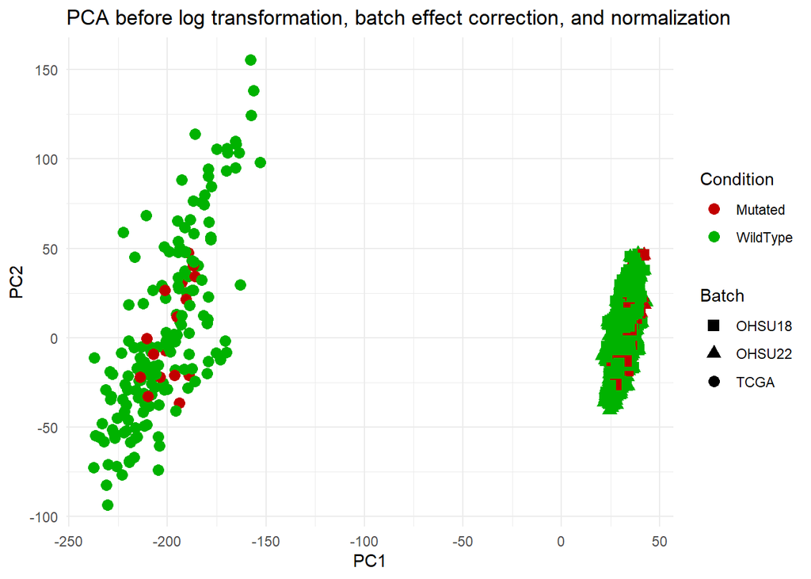

```r
# --- PCA Before Log Transformation, Batch Correction, and Normalization ---

# Combine raw (untransformed, unnormalized, uncorrected) expression matrices
expr_tcga_raw   <- expr_tcga_mat[common_genes, ]
expr_ohsu22_raw <- expr_ohsu22_mat[common_genes, ]
expr_ohsu18_raw <- expr_ohsu18_mat[common_genes, ]
expr_all_raw <- cbind(expr_tcga_raw, expr_ohsu22_raw, expr_ohsu18_raw)

# Build annotation vectors
batch_raw <- c(rep("TCGA", ncol(expr_tcga_raw)),
               rep("OHSU22", ncol(expr_ohsu22_raw)),
               rep("OHSU18", ncol(expr_ohsu18_raw)))
condition_raw <- c(
  pheno_tcga$condition[pheno_tcga$SAMPLE_ID %in% colnames(expr_tcga_raw)],
  pheno_ohsu22$condition[pheno_ohsu22$SAMPLE_ID %in% colnames(expr_ohsu22_raw)],
  pheno_ohsu18$condition[pheno_ohsu18$SAMPLE_ID %in% colnames(expr_ohsu18_raw)]
)

# Run PCA
pca_raw <- prcomp(t(expr_all_raw), scale. = TRUE)

# Prepare data frame for ggplot
pca_df_raw <- data.frame(
  PC1 = pca_raw$x[,1],
  PC2 = pca_raw$x[,2],
  Batch = batch_raw,
  Condition = condition_raw
)

# Define manual shape mapping for Batch
batch_shapes <- c("TCGA" = 16, "OHSU22" = 17, "OHSU18" = 15)

# Define manual color mapping for Condition
condition_colors <- c("WildType" = "#00B200", "Mutated" = "#C20000")

ggplot(pca_df_raw, aes(x = PC1, y = PC2, shape = Batch, color = Condition)) +
  geom_point(size = 3) +
  scale_shape_manual(values = batch_shapes) +
  scale_color_manual(values = condition_colors) +
  theme_minimal() +
  labs(
    title = "PCA before log transformation, batch effect correction, and normalization",
    x = "PC1",
    y = "PC2"
  )
```

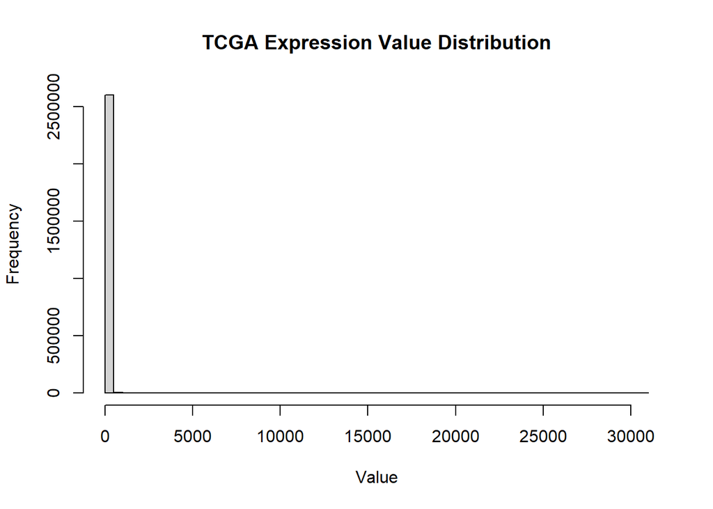

```r
#Expression Value Distribution before loge transformation, batch effect and Normalization

hist(as.numeric(expr_tcga_final), breaks=100, main="TCGA Expression Value Distribution", xlab="Value")
```

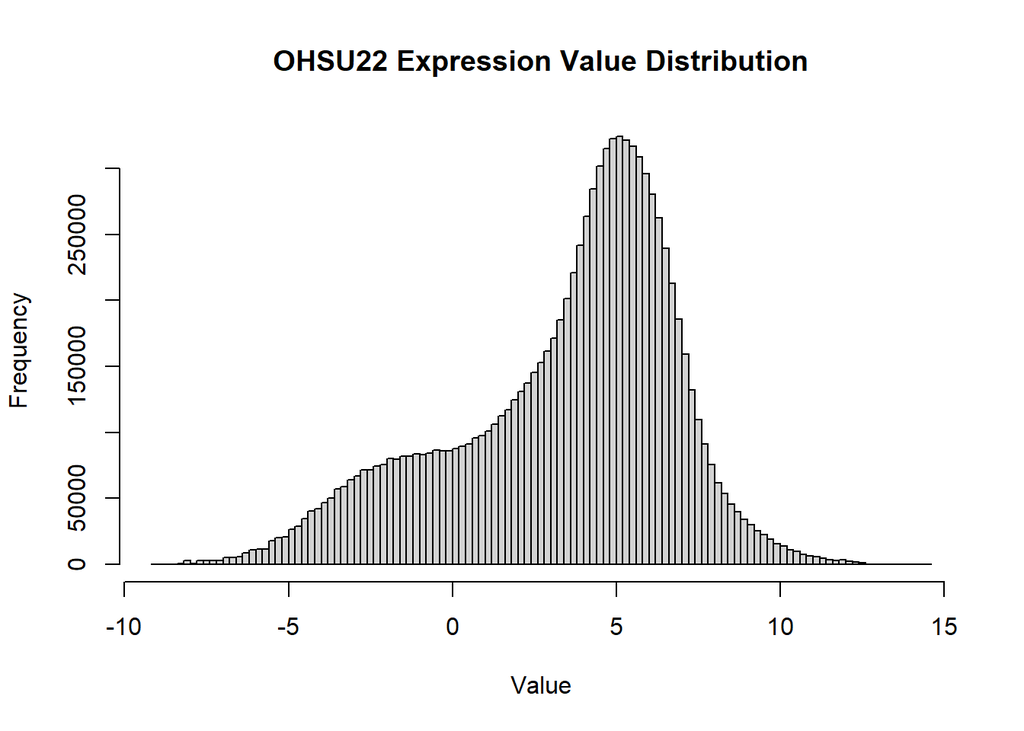

```r
hist(as.numeric(expr_ohsu22_final), breaks=100, main="OHSU22 Expression Value Distribution", xlab="Value")
```

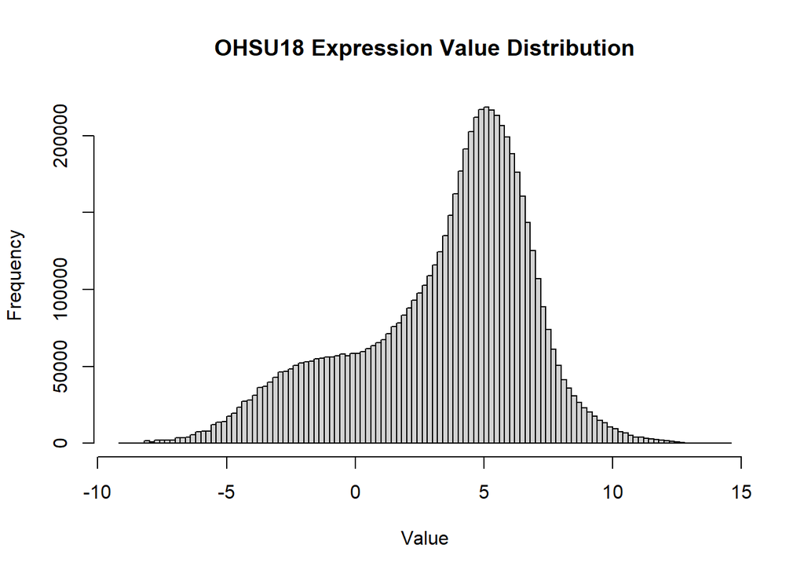

```r
hist(as.numeric(expr_ohsu18_final), breaks=100, main="OHSU18 Expression Value Distribution", xlab="Value")
```

```r
# --- 10. Log2 Transform TCGA Expression Data ---
expr_tcga_final <- log2(expr_tcga_final + 1)


# Combine matrices
combined_matrix <- cbind(expr_tcga_final, expr_ohsu22_final, expr_ohsu18_final)

# Create batch vector
batch <- c(
  rep("TCGA", ncol(expr_tcga_final)),
  rep("OHSU22", ncol(expr_ohsu22_final)),
  rep("OHSU18", ncol(expr_ohsu18_final))
)

# Run ComBat

combat_matrix <- ComBat(dat = as.matrix(combined_matrix), batch = batch, par.prior = TRUE, prior.plots = FALSE)
```

```
## Found 1 genes with uniform expression within a single batch (all zeros); these will not be adjusted for batch.
```

```
## Found3batches
```

```
## Adjusting for0covariate(s) or covariate level(s)
```

```
## Standardizing Data across genes
```

```
## Fitting L/S model and finding priors
```

```
## Finding parametric adjustments
```

```
## Adjusting the Data
```

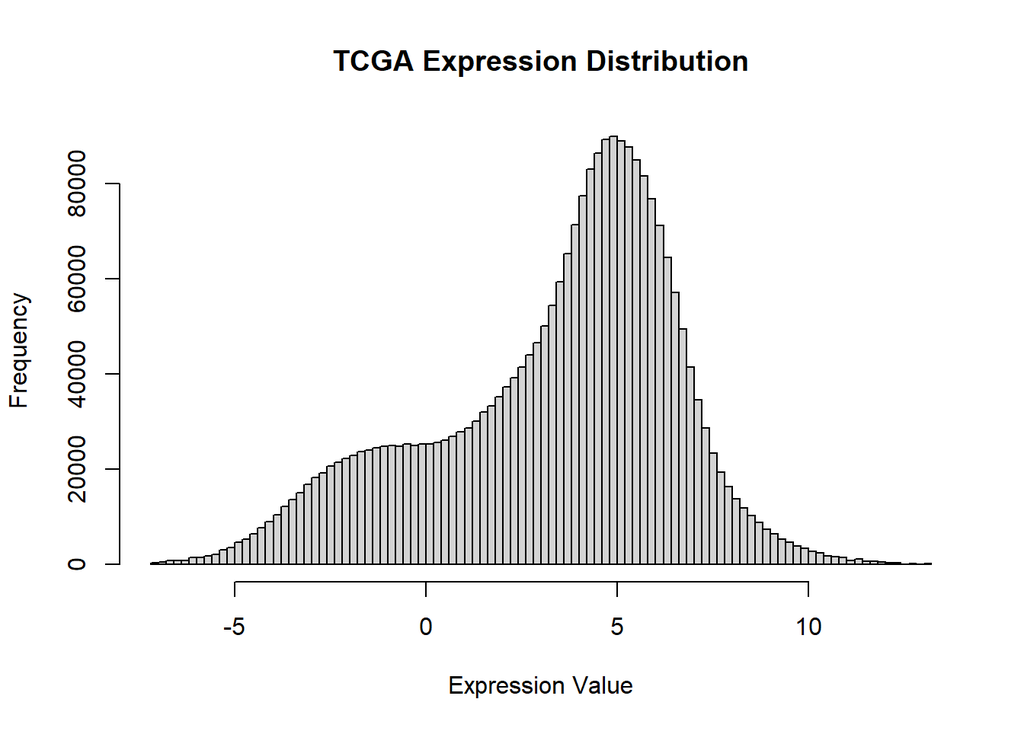

```r
# (Optional) Split back into original datasets
n_tcga <- ncol(expr_tcga_final)
n_ohsu22 <- ncol(expr_ohsu22_final)
n_ohsu18 <- ncol(expr_ohsu18_final)

expr_tcga_final_combat <- combat_matrix[, 1:n_tcga]
expr_ohsu22_final_combat <- combat_matrix[, (n_tcga + 1):(n_tcga + n_ohsu22)]
expr_ohsu18_final_combat <- combat_matrix[, (n_tcga + n_ohsu22 + 1):(n_tcga + n_ohsu22 + n_ohsu18)]


expr_tcga_final <- expr_tcga_final_combat
expr_ohsu22_final <- expr_ohsu22_final_combat
expr_ohsu18_final <- expr_ohsu18_final_combat


qn_matrix <- normalize.quantiles(as.matrix(combat_matrix))
colnames(qn_matrix) <- colnames(combat_matrix)
rownames(qn_matrix) <- rownames(combat_matrix)

n_tcga   <- ncol(expr_tcga_final)
n_ohsu22 <- ncol(expr_ohsu22_final)
n_ohsu18 <- ncol(expr_ohsu18_final)

expr_tcga_final   <- qn_matrix[, 1:n_tcga, drop = FALSE]
expr_ohsu22_final <- qn_matrix[, (n_tcga + 1):(n_tcga + n_ohsu22), drop = FALSE]
expr_ohsu18_final <- qn_matrix[, (n_tcga + n_ohsu22 + 1):(n_tcga + n_ohsu22 + n_ohsu18), drop = FALSE]

#Expression Value Distribution before loge transformation, batch effect and Normalization

hist(as.numeric(expr_tcga_final), breaks=100, main="TCGA Expression Distribution", xlab="Expression Value")
```

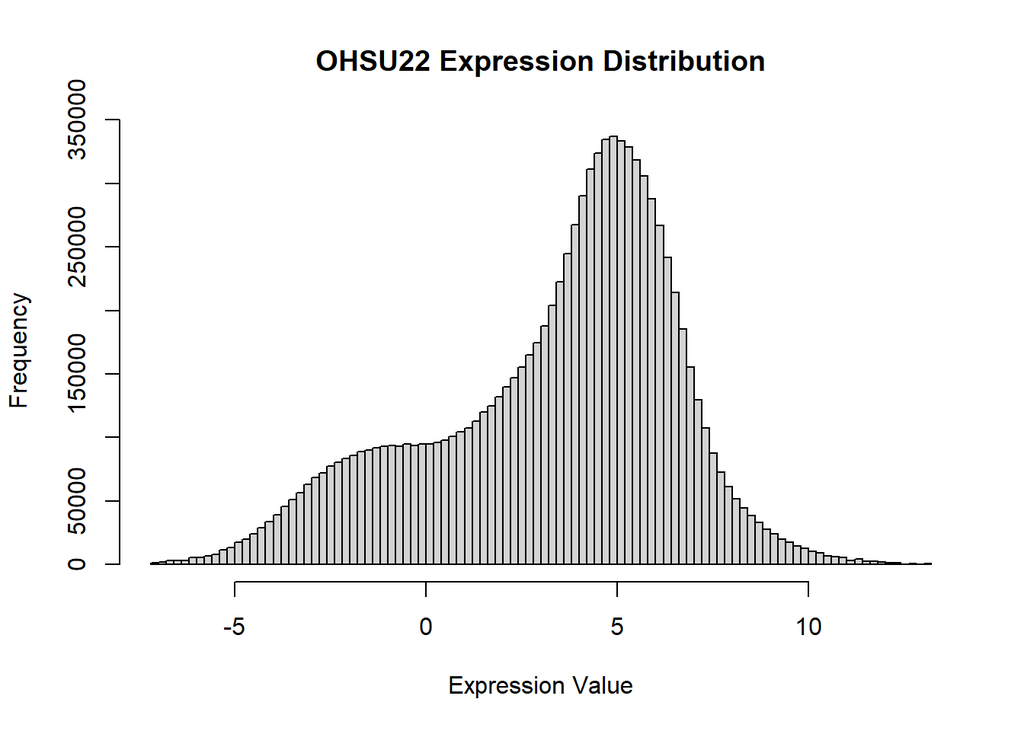

```r
hist(as.numeric(expr_ohsu22_final), breaks=100, main="OHSU22 Expression Distribution", xlab="Expression Value")
```

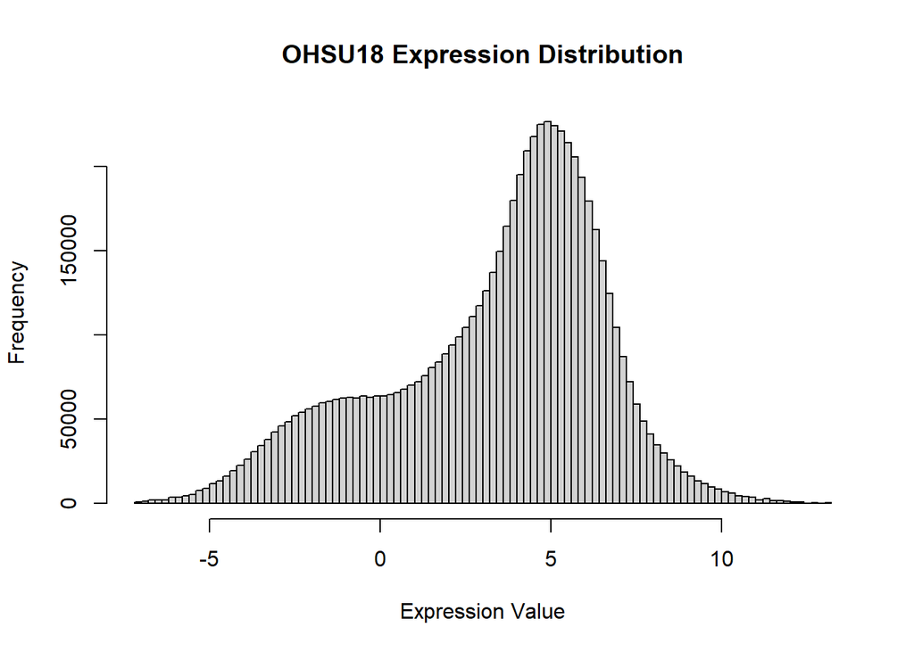

```r
hist(as.numeric(expr_ohsu18_final), breaks=100, main="OHSU18 Expression Distribution", xlab="Expression Value")
```

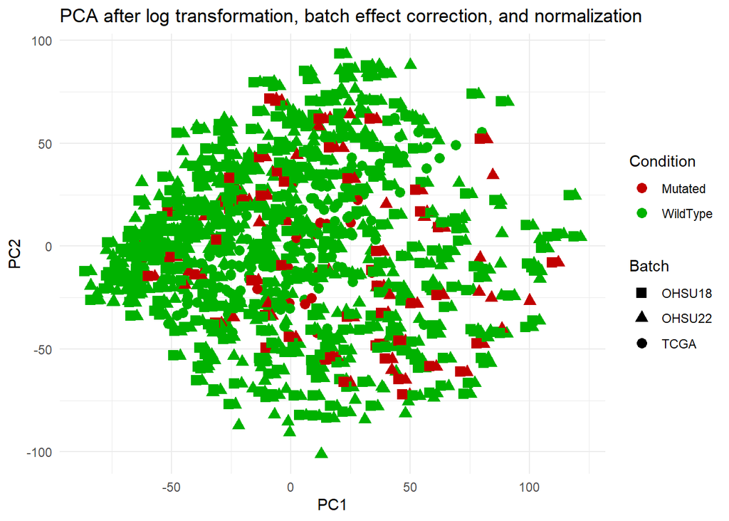

```r
# Combine all samples
expr_all <- cbind(expr_tcga_final, expr_ohsu22_final, expr_ohsu18_final)
pca <- prcomp(t(expr_all), scale. = TRUE)

# Create annotation: batch (TCGA/OHSU22/OHSU18), condition (Mutated/WildType)
batch <- c(rep("TCGA", ncol(expr_tcga_final)),
           rep("OHSU22", ncol(expr_ohsu22_final)),
           rep("OHSU18", ncol(expr_ohsu18_final)))
# Example: combine pheno data for condition
condition <- c(pheno_tcga_filt$condition, pheno_ohsu22_filt$condition, pheno_ohsu18_filt$condition)
pca_df <- data.frame(PC1 = pca$x[,1], PC2 = pca$x[,2], Batch = batch, Condition = condition)


# Define the shapes for Batch
batch_shapes <- c("TCGA" = 16, "OHSU22" = 17, "OHSU18" = 15)

# Define the colors for Condition
condition_colors <- c("WildType" = "#00B200", "Mutated" = "#C20000")

ggplot(pca_df, aes(x = PC1, y = PC2, shape = Batch, color = Condition)) +
  geom_point(size = 3) +
  scale_shape_manual(values = batch_shapes) +
  scale_color_manual(values = condition_colors) +
  theme_minimal() +
  labs(
    title = "PCA after log transformation, batch effect correction, and normalization",
    x = "PC1",
    y = "PC2"
  )
```

# 3.8 Preparation of Data for Meta-Analysis

```r
# --- 1. Reorder Columns to Match Phenotype Order ---
expr_tcga_final   <- expr_tcga_final[, pheno_tcga_filt$SAMPLE_ID]
expr_ohsu22_final <- expr_ohsu22_final[, pheno_ohsu22_filt$SAMPLE_ID]
expr_ohsu18_final <- expr_ohsu18_final[, pheno_ohsu18_filt$SAMPLE_ID]


cat(
  "===== Samples USED in META-ANALYSIS =====\n",
  "TCGA:   ", nrow(pheno_tcga_filt), "samples (Mutated =", sum(pheno_tcga_filt$condition == "Mutated"),
  "| WildType =", sum(pheno_tcga_filt$condition == "WildType"), ")\n",
  "OHSU22: ", nrow(pheno_ohsu22_filt), "samples (Mutated =", sum(pheno_ohsu22_filt$condition == "Mutated"),
  "| WildType =", sum(pheno_ohsu22_filt$condition == "WildType"), ")\n",
  "OHSU18: ", nrow(pheno_ohsu18_filt), "samples (Mutated =", sum(pheno_ohsu18_filt$condition == "Mutated"),
  "| WildType =", sum(pheno_ohsu18_filt$condition == "WildType"), ")\n",
  "TOTAL:  ", nrow(pheno_tcga_filt) + nrow(pheno_ohsu22_filt) + nrow(pheno_ohsu18_filt), "samples\n"
)
```

```
## ===== Samples USED in META-ANALYSIS =====
##  TCGA:    179 samples (Mutated = 16 | WildType = 163 )
##  OHSU22:  671 samples (Mutated = 75 | WildType = 596 )
##  OHSU18:  451 samples (Mutated = 48 | WildType = 403 )
##  TOTAL:   1301 samples
```

# 3.9 Meta-Analysis Using DExMA

```r
# --- 1. DExMA Meta-Analysis & Visualization ---

# 13.1 Ensure sample names match
colnames(expr_tcga_final)   <- pheno_tcga_filt$SAMPLE_ID
rownames(pheno_tcga_filt)   <- pheno_tcga_filt$SAMPLE_ID
colnames(expr_ohsu22_final) <- pheno_ohsu22_filt$SAMPLE_ID
rownames(pheno_ohsu22_filt) <- pheno_ohsu22_filt$SAMPLE_ID
colnames(expr_ohsu18_final) <- pheno_ohsu18_filt$SAMPLE_ID
rownames(pheno_ohsu18_filt) <- pheno_ohsu18_filt$SAMPLE_ID

# 2 Prepare lists for DExMA
expr_list <- list(
  TCGA   = expr_tcga_final,
  OHSU22 = expr_ohsu22_final,
  OHSU18 = expr_ohsu18_final
)
pheno_list <- list(
  TCGA   = pheno_tcga_filt,
  OHSU22 = pheno_ohsu22_filt,
  OHSU18 = pheno_ohsu18_filt
)
namePheno  <- c("condition", "condition", "condition")
expGroups  <- list("Mutated", "Mutated", "Mutated")
refGroups  <- list("WildType", "WildType", "WildType")

# 3 Create DExMA meta-analysis object
objectMA <- createObjectMA(
  listEX     = expr_list,
  listPheno  = pheno_list,
  namePheno  = namePheno,
  expGroups  = expGroups,
  refGroups  = refGroups
)

# 4 Harmonize gene annotation and ensure log2 transformation
objectMA <- allSameID(objectMA, finalID="GeneSymbol", organism="Homo sapiens")
```

```
## Changing IDs
```

[output not shown]

```r
objectMA <- dataLog(objectMA)

# 5 Heterogeneity assessment
heterogeneityTest(objectMA)
```

```
## [1] "I^2 Quantiles"
```

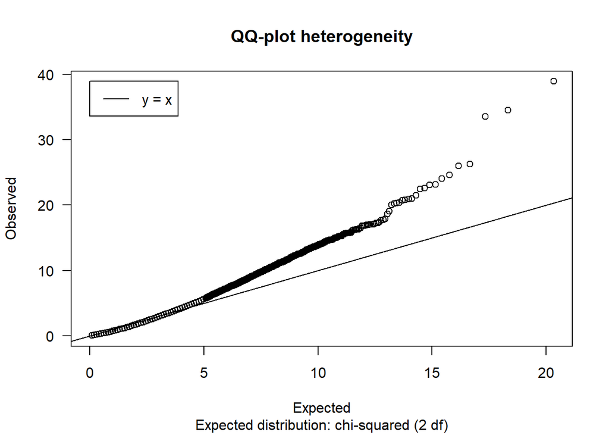

```
##        0%       25%       50%       75%
## 0.0000000 0.0000000 0.0000000 0.2432566
```

```r
# 6 Run meta-analysis (Random Effects Model)
resultsMA <- metaAnalysisDE(
  objectMA,
  typeMethod      = "REM",    # Random Effects Model
  missAllow       = 0.3,
  proportionData  = 0.5
)
```

```
## [1] "Performing Random Effects Model"
```

```r
# 7 Filter for significant & biologically relevant genes
sig_genes <- resultsMA[resultsMA$FDR < 0.05 & abs(resultsMA$AveFC) > 1, ]


# 8 Save significant genes to CSV
write.csv(sig_genes, file = "DExMA_sig_genes_RUNX1.csv", row.names = TRUE)
```

# 3.11 Visualization of Meta-Analysis ResultS

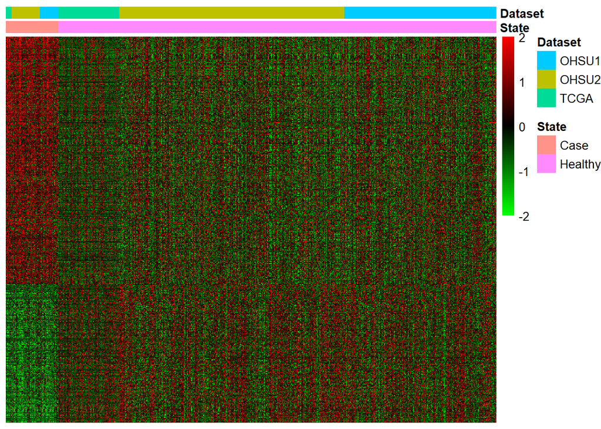

```r
# 1 Visualize: Heatmap of top significant genes

# Custom color palette: green for low, black for mid, red for high
custom_palette <- colorRampPalette(c("green", "black", "red"))(100)

suppressMessages(invisible(capture.output(
  makeHeatmap(
    objectMA,
    resMA         = resultsMA,
    scaling       = "zscor",
    regulation    = "all",
    numSig        = 530,
    fdrSig        = 0.05,
    logFCSig      = 1,
    show_rownames = FALSE,
    col           = custom_palette
  )
)))
```

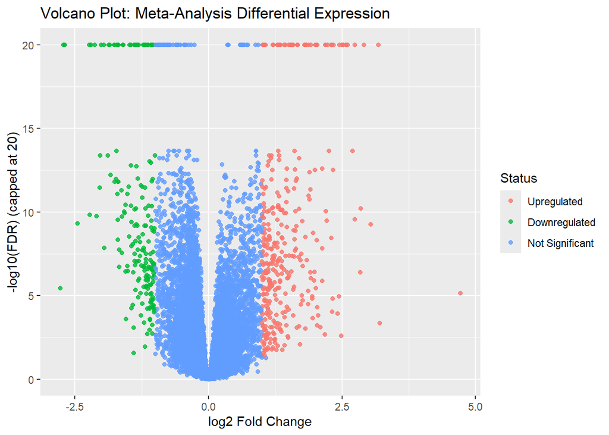

```r
# 2 Visualize: Volcano Plot
resultsMA$gene      <- rownames(resultsMA)
resultsMA$negLogFDR <- -log10(resultsMA$FDR)
logfc_cutoff        <- 1
fdr_cutoff          <- 0.05
resultsMA$Status <- "Not Significant"
resultsMA$Status[resultsMA$AveFC > logfc_cutoff & resultsMA$FDR < fdr_cutoff]  <- "Upregulated"
resultsMA$Status[resultsMA$AveFC < -logfc_cutoff & resultsMA$FDR < fdr_cutoff] <- "Downregulated"
resultsMA$Status <- factor(resultsMA$Status, levels = c("Upregulated", "Downregulated", "Not Significant"))

# Replace FDR == 0 with a very small value (e.g., 1e-300) to avoid Inf
resultsMA$FDR_adj <- ifelse(resultsMA$FDR == 0, 1e-300, resultsMA$FDR)

# Calculate -log10(FDR), capping at a maximum for visualization (e.g., 20)
maxY <- 20
resultsMA$negLogFDR <- -log10(resultsMA$FDR_adj)
resultsMA$negLogFDR_capped <- pmin(resultsMA$negLogFDR, maxY)

# Use negLogFDR_capped in your volcano plot
ggplot(resultsMA, aes(x = AveFC, y = negLogFDR_capped, color = Status)) +
  geom_point(alpha=0.8) +
  # ... (rest of your plot code)
  coord_cartesian(ylim = c(0, maxY)) +
  labs(
    title = "Volcano Plot: Meta-Analysis Differential Expression",
    x = "log2 Fold Change",
    y = "-log10(FDR) (capped at 20)"
  )
```

```r
# 3 Completion Message
cat(sprintf("Meta-analysis complete. %d significant genes saved to DExMA_sig_genes_RUNX1.csv\n", nrow(sig_genes)))
```

```
## Meta-analysis complete. 530 significant genes saved to DExMA_sig_genes_RUNX1.csv
```

# 3.11 Functional Enrichment Analysis

```r
# --- 1. Prepare gene list ---
# sig_genes should be your significant gene table. We'll use gene symbols.
sig_genes <- resultsMA[resultsMA$FDR < 0.05 & abs(resultsMA$AveFC) > 1, ]
gene_list <- sig_genes$gene
# --- 2.convert gene symbols to Entrez IDs (required for KEGG) ---
# Convert gene symbols to Entrez IDs
gene_df <- bitr(gene_list, fromType = "SYMBOL",
                toType = "ENTREZID", OrgDb = org.Hs.eg.db)
entrez_genes <- gene_df$ENTREZID

# --- 3. GO Enrichment (Biological Process example) ---
ego <- enrichGO(gene         = gene_list,
                OrgDb        = org.Hs.eg.db,
                keyType      = "SYMBOL",
                ont          = "BP",        # "BP"=Biological Process, "MF"=Molecular Function, "CC"=Cellular Component
                pAdjustMethod = "BH",
                pvalueCutoff  = 0.05,
                qvalueCutoff  = 0.2,
                readable      = TRUE)


# Extract results as a data.frame
ego_df <- as.data.frame(ego)

# Calculate % of input genes in each term
ego_df$Percent <- round(100 * ego_df$Count / sum(ego_df$Count), 2)

# Create a new data frame with your desired columns, sorted by Count
topN <- 15
top_ego <- ego_df[order(-ego_df$Count), ][1:topN, ]

# Build the final table
result_table <- data.frame(
  Category = rep("BP", nrow(top_ego)),  # or ego@ontology if available
  GO_ID = top_ego$ID,
  Term = top_ego$Description,
  Count = top_ego$Count,
  Percent = top_ego$Percent,
  P_value = signif(top_ego$pvalue, 3)
)
print(result_table)
```

```
##    Category      GO_ID                                          Term Count
## 1        BP GO:0007409                                  axonogenesis    34
## 2        BP GO:0006935                                    chemotaxis    32
## 3        BP GO:0042330                                         taxis    32
## 4        BP GO:0007389                 pattern specification process    29
## 5        BP GO:0050867        positive regulation of cell activation    28
## 6        BP GO:0045785          positive regulation of cell adhesion    28
## 7        BP GO:0002009                morphogenesis of an epithelium    28
## 8        BP GO:0050900                           leukocyte migration    26
## 9        BP GO:0007159                  leukocyte cell-cell adhesion    26
## 10       BP GO:0030198             extracellular matrix organization    25
## 11       BP GO:0043062          extracellular structure organization    25
## 12       BP GO:0045229 external encapsulating structure organization    25
## 13       BP GO:0045765                    regulation of angiogenesis    25
## 14       BP GO:1901342         regulation of vasculature development    25
```

[output cut: 17 more lines]

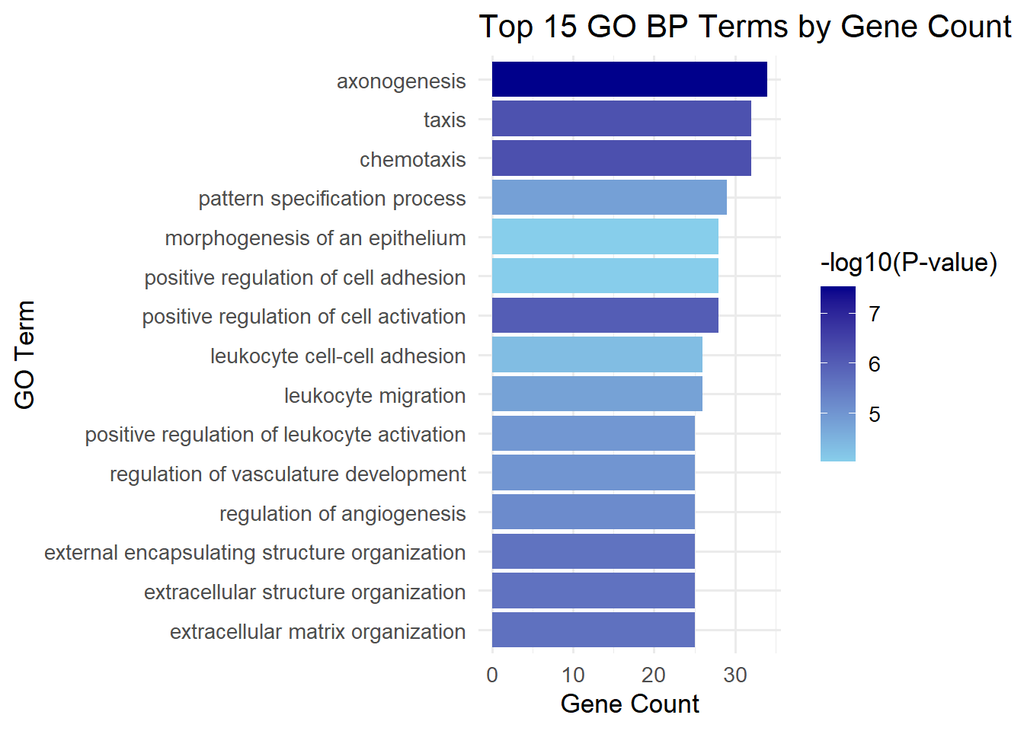

```r
# Order factors by Count for plotting
result_table$Term <- factor(result_table$Term, levels = result_table$Term[order(result_table$Count)])

ggplot(result_table, aes(x = Term, y = Count, fill = -log10(P_value))) +
  geom_bar(stat = "identity") +
  coord_flip() +
  scale_fill_gradient(low = "skyblue", high = "darkblue", name = "-log10(P-value)") +
  labs(
    title = "Top 15 GO BP Terms by Gene Count",
    x = "GO Term",
    y = "Gene Count"
  ) +
  theme_minimal(base_size = 13)
```

```r
# --- 4. KEGG Pathway Enrichment ---
ekegg <- enrichKEGG(gene         = entrez_genes,
                    organism     = 'hsa',
                    pvalueCutoff = 0.05)
```

```
## Reading KEGG annotation online: "https://rest.kegg.jp/link/hsa/pathway"...
```

```
## Reading KEGG annotation online: "https://rest.kegg.jp/list/pathway/hsa"...
```

```r
# Split Entrez IDs and map to gene symbols
convert_entrez_to_symbol <- function(entrez_str) {
  entrez_vec <- unlist(strsplit(entrez_str, "/"))
  # Remove any empty entries
  entrez_vec <- entrez_vec[entrez_vec != ""]
  # Map to gene symbol
  gene_symbols <- mapIds(org.Hs.eg.db, entrez_vec, "SYMBOL", "ENTREZID")
  # Collapse back to string
  paste(gene_symbols, collapse = "/")
}

# Replace geneID column with gene symbols
ekegg@result$geneSymbol <- sapply(ekegg@result$geneID, convert_entrez_to_symbol)
# Convert Entrez IDs in geneID to gene symbols
convert_entrez_to_symbol <- function(entrez_str) {
  entrez_vec <- unlist(strsplit(entrez_str, "/"))
  entrez_vec <- entrez_vec[entrez_vec != ""]
  gene_symbols <- mapIds(org.Hs.eg.db, entrez_vec, "SYMBOL", "ENTREZID", multiVals="first")
  paste(gene_symbols, collapse = "/")
}

ekegg_df <- as.data.frame(ekegg)
ekegg_df$Percent <- round(100 * ekegg_df$Count / sum(ekegg_df$Count), 2)
top15 <- ekegg_df[order(-ekegg_df$Count), ][1:15, ]
top15$Genes <- sapply(top15$geneID, convert_entrez_to_symbol)
# Build the result table
result_table <- data.frame(
  Pathway_ID = top15$ID,
  Name = top15$Description,
  Count = top15$Count,
  Percent = top15$Percent,
  P_value = signif(top15$pvalue, 3),
  Genes = top15$Genes
)

# View the table
print(result_table, row.names = FALSE)
```

```
##  Pathway_ID                                    Name Count Percent  P_value
##    hsa04514                 Cell adhesion molecules    24    4.27 7.98e-12
##    hsa05152                            Tuberculosis    20    3.56 1.10e-07
##    hsa05166 Human T-cell leukemia virus 1 infection    20    3.56 3.09e-06
##    hsa04640              Hematopoietic cell lineage    19    3.38 1.88e-11
##    hsa05164                             Influenza A    19    3.38 2.34e-07
##    hsa04151              PI3K-Akt signaling pathway    19    3.38 4.89e-03
##    hsa04080 Neuroactive ligand-receptor interaction    19    3.38 6.16e-03
##    hsa05145                           Toxoplasmosis    18    3.20 1.15e-09
##    hsa04145                               Phagosome    17    3.02 1.50e-06
##    hsa04360                           Axon guidance    16    2.85 4.25e-05
##    hsa05169            Epstein-Barr virus infection    16    2.85 1.45e-04
##    hsa05150         Staphylococcus aureus infection    15    2.67 9.89e-08
##    hsa05168        Herpes simplex virus 1 infection    15    2.67 1.35e-04
##    hsa05416                       Viral myocarditis    14    2.49 4.52e-09
##    hsa04612     Antigen processing and presentation    14    2.49 3.26e-08
##                                                                                                                                                                            Genes
##  CNTN1/VCAN/NTNG2/HLA-DMA/HLA-DMB/HLA-DOA/HLA-DPA1/HLA-DPB1/HLA-DQA1/HLA-DQA2/HLA-DQB1/HLA-DQB2/HLA-DRA/HLA-DRB1/HLA-DRB5/ITGA9/PTPRF/PTPRM/PVR/NECTIN1/CLDN12/CD34/CDH4/SLITRK5
##                             CLEC7A/HLA-DMA/HLA-DMB/HLA-DOA/HLA-DPA1/HLA-DPB1/HLA-DQA1/HLA-DQA2/HLA-DQB1/HLA-DQB2/HLA-DRA/HLA-DRB1/HLA-DRB5/IL10RA/LSP1/CIITA/NOS2/CD14/MRC2/AKT3
##                             HLA-DMA/HLA-DMB/HLA-DOA/HLA-DPA1/HLA-DPB1/HLA-DQA1/HLA-DQA2/HLA-DQB1/HLA-DQB2/HLA-DRA/HLA-DRB1/HLA-DRB5/IL2RA/IL15/CCND1/IL1R2/NRP1/CCNA1/AKT3/ADCY1
##                                     DNTT/HLA-DMA/HLA-DMB/HLA-DOA/HLA-DPA1/HLA-DPB1/HLA-DQA1/HLA-DQA2/HLA-DQB1/HLA-DQB2/HLA-DRA/HLA-DRB1/HLA-DRB5/IL2RA/IL1R2/CD1C/CD1E/CD14/CD34
##                                   NXF3/TPSB2/HLA-DMA/HLA-DMB/HLA-DOA/HLA-DPA1/HLA-DPB1/HLA-DQA1/HLA-DQA2/HLA-DQB1/HLA-DQB2/HLA-DRA/HLA-DRB1/HLA-DRB5/CIITA/MX1/TPSAB1/AKT3/TPSD1
##                                                                  COL4A5/COL6A2/EFNA1/COL6A6/FGFR3/FGFR2/FN1/COL6A5/GNG11/LPAR4/IL2RA/ITGA9/LAMA3/PTK2/CCND1/BDNF/ARTN/AKT3/LPAR6
##                                                                   CTSG/ADRB1/RXFP1/AGT/F2RL1/LPAR4/GRID1/HTR1F/POMC/PTGER3/PTGIR/AVPR1B/SCT/TRH/C3AR1/CHRNA6/P2RY14/LPAR6/CALCRL
##                                       GNAI1/HLA-DMA/HLA-DMB/HLA-DOA/HLA-DPA1/HLA-DPB1/HLA-DQA1/HLA-DQA2/HLA-DQB1/HLA-DQB2/HLA-DRA/HLA-DRB1/HLA-DRB5/IL10RA/LAMA3/CIITA/NOS2/AKT3
##                                                CLEC7A/HLA-DMA/HLA-DMB/HLA-DOA/HLA-DPA1/HLA-DPB1/HLA-DQA1/HLA-DQA2/HLA-DQB1/HLA-DQB2/HLA-DRA/HLA-DRB1/HLA-DRB5/MPO/MSR1/CD14/MRC2
##                                                                                 ENAH/PARD3/SEMA6A/EFNA1/EFNB1/NTNG2/EPHB1/EPHB2/PLXNA4/GNAI1/PTK2/WNT5A/UNC5C/NRP1/SRGAP3/SEMA3C
##                                                    BLNK/HLA-DMA/HLA-DMB/HLA-DOA/HLA-DPA1/HLA-DPB1/HLA-DQA1/HLA-DQA2/HLA-DQB1/HLA-DQB2/HLA-DRA/HLA-DRB1/HLA-DRB5/CCND1/CCNA1/AKT3
##                                                        HLA-DMA/HLA-DMB/HLA-DOA/HLA-DPA1/HLA-DPB1/HLA-DQA1/HLA-DQA2/HLA-DQB1/HLA-DQB2/HLA-DRA/HLA-DRB1/HLA-DRB5/KRT17/KRT18/C3AR1
##                                                        NXF3/HLA-DMA/HLA-DMB/HLA-DOA/HLA-DPA1/HLA-DPB1/HLA-DQA1/HLA-DQA2/HLA-DQB1/HLA-DQB2/HLA-DRA/HLA-DRB1/HLA-DRB5/NECTIN1/AKT3
##                                                               HLA-DMA/HLA-DMB/HLA-DOA/HLA-DPA1/HLA-DPB1/HLA-DQA1/HLA-DQA2/HLA-DQB1/HLA-DQB2/HLA-DRA/HLA-DRB1/HLA-DRB5/CCND1/SGCE
##                                                               HLA-DMA/HLA-DMB/HLA-DOA/HLA-DPA1/HLA-DPB1/HLA-DQA1/HLA-DQA2/HLA-DQB1/HLA-DQB2/HLA-DRA/HLA-DRB1/HLA-DRB5/CIITA/LGMN
```

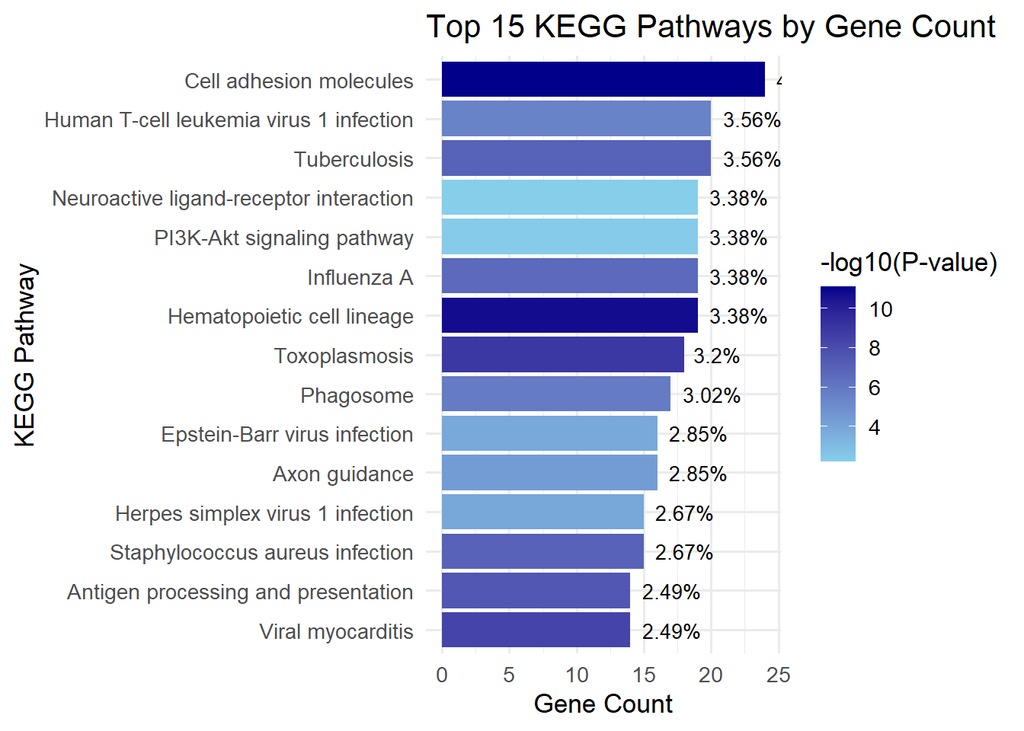

```r
write.csv(result_table, "KEGG_top15_table.csv", row.names = FALSE)


# 4. Barplot for top 15 KEGG pathways by gene count
# Order Name factor so bars are sorted by Count
result_table$Name <- factor(result_table$Name, levels = result_table$Name[order(result_table$Count)])

ggplot(result_table, aes(x = Name, y = Count, fill = -log10(P_value))) +
  geom_bar(stat = "identity") +
  coord_flip() +
  scale_fill_gradient(low = "skyblue", high = "darkblue", name = "-log10(P-value)") +
  geom_text(aes(label = paste0(Percent, "%")), hjust = -0.2, size = 3.5) +
  labs(
    title = "Top 15 KEGG Pathways by Gene Count",
    x = "KEGG Pathway",
    y = "Gene Count"
  ) +
  theme_minimal(base_size = 13)
```

```r
write.table(sig_genes$gene, file = "sig_gene_list.txt", quote = FALSE, row.names = FALSE, col.names = FALSE)
```

# 3.12 Protein-Protein Interaction Network and Hub Gene Analysis

#functional enrichment analysis for top 3 modules

To identify densely connected regions within the protein-protein interaction (PPI) network, module detection was performed using the MCODE (Molecular Complex Detection) plugin in Cytoscape. This approach helps uncover functional subnetworks or clusters that may represent protein complexes or pathway-related gene groups. The PPI network constructed from meta-significant DEGs (confidence score > 0.45) was imported into Cytoscape, and MCODE was used to identify and extract the top three highly interconnected modules. The resulting gene clusters were exported for downstream functional enrichment analysis.

```r
# Load the module file
df_module_1 <- read.csv("module1.csv")

# Extract gene names (assuming "shared.name" column holds symbols)
gene_list_module_1 <- unique(df_module_1$shared.name)


# Perform enrichment
module_1_ego <- enrichGO(gene         = gene_list_module_1,
                         OrgDb        = org.Hs.eg.db,
                         keyType      = "SYMBOL",
                         ont          = "BP",        # "BP": Biological Process, "MF": Molecular Function, "CC": Cellular Component
                         pAdjustMethod = "BH",
                         pvalueCutoff  = 0.05,
                         qvalueCutoff  = 0.2)


# Convert enrichGO result to data frame
module_1_ego_df <- as.data.frame(module_1_ego)

# Select and rename columns
final_module_1_go <- module_1_ego_df[, c("ID", "Description", "Count", "pvalue", "geneID")]
colnames(final_module_1_go) <- c("ID", "Term", "Count", "P value", "Genes")


# Get top 10 by Count (descending)
top10 <- final_module_1_go[order(-final_module_1_go$Count), ][1:10, ]



# Select the top 5 by Count
top5 <- top10[order(-top10$Count), ][1:5, ]
print(top5)
```

```
##                    ID
## GO:0019886 GO:0019886
## GO:0002495 GO:0002495
## GO:0002504 GO:0002504
## GO:0002478 GO:0002478
## GO:0019884 GO:0019884
##                                                                                                 Term
## GO:0019886         antigen processing and presentation of exogenous peptide antigen via MHC class II
## GO:0002495                   antigen processing and presentation of peptide antigen via MHC class II
## GO:0002504 antigen processing and presentation of peptide or polysaccharide antigen via MHC class II
## GO:0002478                          antigen processing and presentation of exogenous peptide antigen
## GO:0019884                                  antigen processing and presentation of exogenous antigen
##            Count      P value
## GO:0019886    13 4.330873e-37
## GO:0002495    13 3.099386e-36
## GO:0002504    13 7.478220e-36
## GO:0002478    13 3.698026e-35
## GO:0019884    13 7.444376e-34
##                                                                                                                   Genes
## GO:0019886 LGMN/HLA-DQA2/HLA-DMB/HLA-DMA/HLA-DRB1/HLA-DQA1/HLA-DQB1/HLA-DPB1/HLA-DRA/HLA-DRB5/HLA-DOA/HLA-DQB2/HLA-DPA1
## GO:0002495 LGMN/HLA-DQA2/HLA-DMB/HLA-DMA/HLA-DRB1/HLA-DQA1/HLA-DQB1/HLA-DPB1/HLA-DRA/HLA-DRB5/HLA-DOA/HLA-DQB2/HLA-DPA1
## GO:0002504 LGMN/HLA-DQA2/HLA-DMB/HLA-DMA/HLA-DRB1/HLA-DQA1/HLA-DQB1/HLA-DPB1/HLA-DRA/HLA-DRB5/HLA-DOA/HLA-DQB2/HLA-DPA1
## GO:0002478 LGMN/HLA-DQA2/HLA-DMB/HLA-DMA/HLA-DRB1/HLA-DQA1/HLA-DQB1/HLA-DPB1/HLA-DRA/HLA-DRB5/HLA-DOA/HLA-DQB2/HLA-DPA1
## GO:0019884 LGMN/HLA-DQA2/HLA-DMB/HLA-DMA/HLA-DRB1/HLA-DQA1/HLA-DQB1/HLA-DPB1/HLA-DRA/HLA-DRB5/HLA-DOA/HLA-DQB2/HLA-DPA1
```

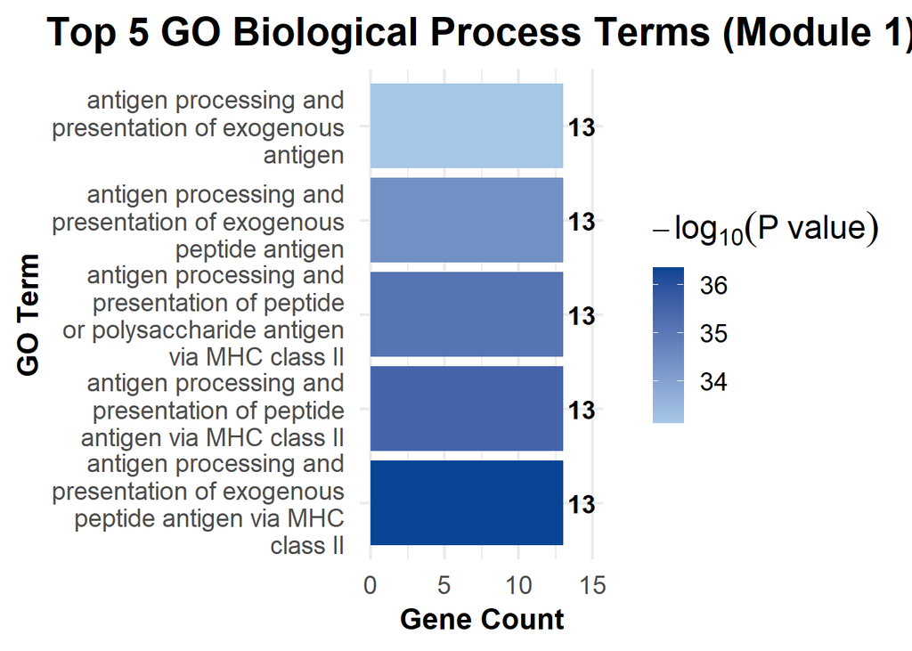

```r
# Wrap GO term text to two lines (e.g., 25 characters per line)
top5$Term_wrapped <- str_wrap(top5$Term, width = 25)
top5$Term_wrapped <- factor(top5$Term_wrapped, levels = top5$Term_wrapped[order(top5$Count)])

# Create the bar plot
ggplot(top5, aes(x = Term_wrapped, y = Count, fill = -log10(`P value`))) +
  geom_bar(stat = "identity", width = 0.9) +
  coord_flip() +
  scale_fill_gradient(low = "#a7c7e7", high = "#084594", name = expression(-log[10](P~value))) +
  labs(
    title = "Top 5 GO Biological Process Terms (Module 1)",
    x = "GO Term",
    y = "Gene Count"
  ) +
  geom_text(aes(label = Count), hjust = -0.15, size = 5, fontface = "bold") +
  theme_minimal(base_size = 18) +
  theme(
    plot.title = element_text(hjust = 0.5, face = "bold"),
    axis.title.y = element_text(face = "bold", size = 16),
    axis.title.x = element_text(face = "bold", size = 16),
    axis.text.y = element_text(size = 14),
    legend.position = "right"
  ) +
  expand_limits(y = max(top5$Count) + 2)
```

```r
# Load the module 2 file
df_module_2 <- read.csv("module2.csv")

# Extract gene names (assuming "shared.name" column holds symbols)
gene_list_module_2 <- unique(df_module_2$shared.name)

# Perform enrichment
module_2_ego <- enrichGO(
  gene         = gene_list_module_2,
  OrgDb        = org.Hs.eg.db,
  keyType      = "SYMBOL",
  ont          = "BP",        # "BP": Biological Process, "MF": Molecular Function, "CC": Cellular Component
  pAdjustMethod = "BH",
  pvalueCutoff  = 0.05,
  qvalueCutoff  = 0.2
)

# Convert enrichGO result to data frame
module_2_ego_df <- as.data.frame(module_2_ego)

# Select and rename columns
final_module_2_go <- module_2_ego_df[, c("ID", "Description", "Count", "pvalue", "geneID")]
colnames(final_module_2_go) <- c("ID", "Term", "Count", "P value", "Genes")

# Save to CSV
write.csv(final_module_2_go, "module2_GO_enrichment_selected_columns.csv", row.names = FALSE)

# Get top 10 by Count (descending)
top10_module_2 <- final_module_2_go[order(-final_module_2_go$Count), ][1:10, ]


# Read the CSV for module 2 top 10
#top10_module_2 <- read.csv("module2_GO_enrichment_top10_by_count.csv")

# Select the top 5 by Count
top5_module_2 <- top10_module_2[order(-top10_module_2$Count), ][1:5, ]
print(top5_module_2)
```

```
##                    ID                                 Term Count      P value
## GO:0050673 GO:0050673        epithelial cell proliferation     4 1.438610e-03
## GO:0060749 GO:0060749   mammary gland alveolus development     3 9.582514e-07
## GO:0061377 GO:0061377     mammary gland lobule development     3 9.582514e-07
## GO:0061180 GO:0061180 mammary gland epithelium development     3 5.010134e-05
## GO:1904019 GO:1904019    epithelial cell apoptotic process     3 7.798646e-05
##                         Genes
## GO:0050673 AR/ESR1/CD34/CCND1
## GO:0060749      AR/ESR1/CCND1
## GO:0061377      AR/ESR1/CCND1
## GO:0061180      AR/ESR1/CCND1
## GO:1904019    ESR1/KRT8/KRT18
```

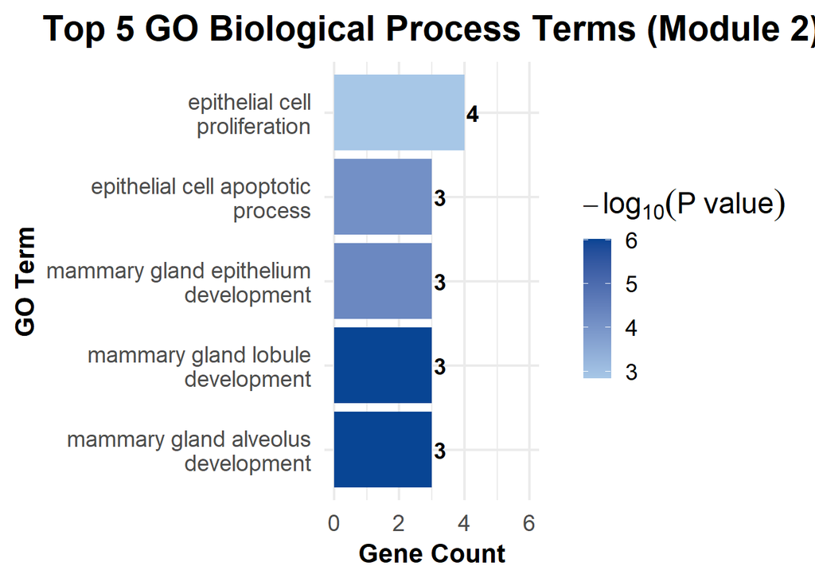

```r
# Wrap GO term text to two lines (e.g., 25 characters per line)
top5_module_2$Term_wrapped <- str_wrap(top5_module_2$Term, width = 25)
top5_module_2$Term_wrapped <- factor(top5_module_2$Term_wrapped, levels = top5_module_2$Term_wrapped[order(top5_module_2$Count)])

# Plot
ggplot(top5_module_2, aes(x = Term_wrapped, y = Count, fill = -log10(`P value`))) +
  geom_bar(stat = "identity", width = 0.9) +
  coord_flip() +
  scale_fill_gradient(low = "#a7c7e7", high = "#084594", name = expression(-log[10](P~value))) +
  labs(
    title = "Top 5 GO Biological Process Terms (Module 2)",
    x = "GO Term",
    y = "Gene Count"
  ) +
  geom_text(aes(label = Count), hjust = -0.15, size = 5, fontface = "bold") +
  theme_minimal(base_size = 18) +
  theme(
    plot.title = element_text(hjust = 0.5, face = "bold"),
    axis.title.y = element_text(face = "bold", size = 16),
    axis.title.x = element_text(face = "bold", size = 16),
    axis.text.y = element_text(size = 14),
    legend.position = "right"
  ) +
  expand_limits(y = max(top5_module_2$Count) + 2)
```

```r
# Load the module 3 file
df_module_3 <- read.csv("module3.csv")

# Extract gene names (assuming "shared.name" column holds symbols)
gene_list_module_3 <- unique(df_module_3$shared.name)


# Perform enrichment
module_3_ego <- enrichGO(
  gene         = gene_list_module_3,
  OrgDb        = org.Hs.eg.db,
  keyType      = "SYMBOL",
  ont          = "BP",        # "BP": Biological Process, "MF": Molecular Function, "CC": Cellular Component
  pAdjustMethod = "BH",
  pvalueCutoff  = 0.05,
  qvalueCutoff  = 0.2
)

# Convert enrichGO result to data frame
module_3_ego_df <- as.data.frame(module_3_ego)

# Select and rename columns
final_module_3_go <- module_3_ego_df[, c("ID", "Description", "Count", "pvalue", "geneID")]
colnames(final_module_3_go) <- c("ID", "Term", "Count", "P value", "Genes")

# Save to CSV
write.csv(final_module_3_go, "module3_GO_enrichment_selected_columns.csv", row.names = FALSE)

# Get top 10 by Count (descending)
top10_module_3 <- final_module_3_go[order(-final_module_3_go$Count), ][1:10, ]


# Read the GO enrichment results for module 3
final_module_3_go <- top10_module_3

# Select the top 5 by Count (descending order)
top5_module_3 <- final_module_3_go[order(-final_module_3_go$Count), ][1:5, ]
print(top5_module_3)
```

```
##                    ID
## GO:0030198 GO:0030198
## GO:0043062 GO:0043062
## GO:0045229 GO:0045229
## GO:0038063 GO:0038063
## GO:0045906 GO:0045906
##                                                                     Term Count
## GO:0030198                             extracellular matrix organization     2
## GO:0043062                          extracellular structure organization     2
## GO:0045229                 external encapsulating structure organization     2
## GO:0038063 collagen-activated tyrosine kinase receptor signaling pathway     1
## GO:0045906                       negative regulation of vasoconstriction     1
##                P value         Genes
## GO:0030198 0.004547030 COL4A5/COL8A2
## GO:0043062 0.004573289 COL4A5/COL8A2
## GO:0045229 0.004599619 COL4A5/COL8A2
## GO:0038063 0.003471671        COL4A5
## GO:0045906 0.003786779         ITGA9
```

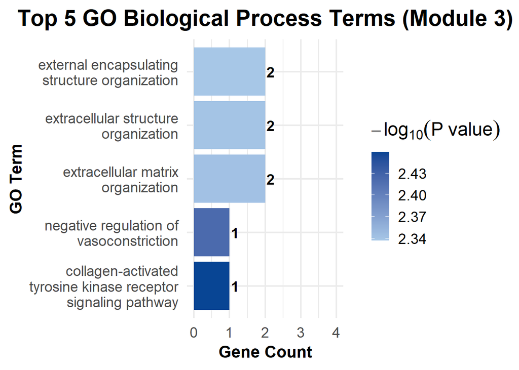

```r
# Wrap GO term text to two lines (e.g., 25 characters per line)
top5_module_3$Term_wrapped <- str_wrap(top5_module_3$Term, width = 25)
top5_module_3$Term_wrapped <- factor(top5_module_3$Term_wrapped, levels = top5_module_3$Term_wrapped[order(top5_module_3$Count)])

# Bar plot
ggplot(top5_module_3, aes(x = Term_wrapped, y = Count, fill = -log10(`P value`))) +
  geom_bar(stat = "identity", width = 0.9) +
  coord_flip() +
  scale_fill_gradient(low = "#a7c7e7", high = "#084594", name = expression(-log[10](P~value))) +
  labs(
    title = "Top 5 GO Biological Process Terms (Module 3)",
    x = "GO Term",
    y = "Gene Count"
  ) +
  geom_text(aes(label = Count), hjust = -0.15, size = 5, fontface = "bold") +
  theme_minimal(base_size = 18) +
  theme(
    plot.title = element_text(hjust = 0.5, face = "bold"),
    axis.title.y = element_text(face = "bold", size = 16),
    axis.title.x = element_text(face = "bold", size = 16),
    axis.text.y = element_text(size = 14),
    legend.position = "right"
  ) +
  expand_limits(y = max(top5_module_3$Count) + 2)
```

#functional enrichment analysis for Shortest path Hub genes

To identify the most central and functionally relevant genes within the protein-protein interaction (PPI) network, hub gene analysis was conducted using the CytoHubba plugin in Cytoscape. The Maximal Clique Centrality (MCC) algorithm was employed, which ranks nodes based on their involvement in densely connected subnetworks and the number of shortest paths they participate in. The top 10 hub genes with the highest MCC scores were selected as key regulatory genes. These genes were subsequently used for functional enrichment analysis to explore their associated biological processes and pathways.

```r
# Load the hub gene file
df_hub <- read.csv("MCC_top10_with_shortest_paths default node.csv")

# Extract gene names (assuming "shared.name" column holds symbols)
gene_list_hub <- unique(df_hub$shared.name)


# Perform GO enrichment analysis (Biological Process)
hub_ego <- enrichGO(
  gene         = gene_list_hub,
  OrgDb        = org.Hs.eg.db,
  keyType      = "SYMBOL",
  ont          = "BP",        # "BP": Biological Process
  pAdjustMethod = "BH",
  pvalueCutoff  = 0.05,
  qvalueCutoff  = 0.2
)

# View results

# Convert enrichGO result to data frame
hub_ego_df <- as.data.frame(hub_ego)

# Select and rename columns
final_hub_go <- hub_ego_df[, c("ID", "Description", "Count", "pvalue", "geneID")]
colnames(final_hub_go) <- c("ID", "Term", "Count", "P value", "Genes")

# Save to CSV
write.csv(final_hub_go, "hub_GO_enrichment_selected_columns.csv", row.names = FALSE)

# Get top 10 by Count (descending)
top10_hub <- final_hub_go[order(-final_hub_go$Count), ][1:10, ]


# Read the GO enrichment results for hub
final_hub_go <- top10_hub

# Select the top 5 by Count (descending order)
top5_hub <- final_hub_go[order(-final_hub_go$Count), ][1:5, ]
print(top5_hub)
```

```
##                    ID
## GO:0002399 GO:0002399
## GO:0002503 GO:0002503
## GO:0002396 GO:0002396
## GO:0002501 GO:0002501
## GO:0019886 GO:0019886
##                                                                                         Term
## GO:0002399                                             MHC class II protein complex assembly
## GO:0002503                        peptide antigen assembly with MHC class II protein complex
## GO:0002396                                                      MHC protein complex assembly
## GO:0002501                                 peptide antigen assembly with MHC protein complex
## GO:0019886 antigen processing and presentation of exogenous peptide antigen via MHC class II
##            Count      P value
## GO:0002399    10 4.786101e-33
## GO:0002503    10 4.786101e-33
## GO:0002396    10 2.108060e-31
## GO:0002501    10 2.108060e-31
## GO:0019886    10 2.650773e-29
##                                                                                             Genes
## GO:0002399 HLA-DRB1/HLA-DQB2/HLA-DPA1/HLA-DMA/HLA-DRA/HLA-DQA2/HLA-DPB1/HLA-DMB/HLA-DQB1/HLA-DQA1
## GO:0002503 HLA-DRB1/HLA-DQB2/HLA-DPA1/HLA-DMA/HLA-DRA/HLA-DQA2/HLA-DPB1/HLA-DMB/HLA-DQB1/HLA-DQA1
## GO:0002396 HLA-DRB1/HLA-DQB2/HLA-DPA1/HLA-DMA/HLA-DRA/HLA-DQA2/HLA-DPB1/HLA-DMB/HLA-DQB1/HLA-DQA1
## GO:0002501 HLA-DRB1/HLA-DQB2/HLA-DPA1/HLA-DMA/HLA-DRA/HLA-DQA2/HLA-DPB1/HLA-DMB/HLA-DQB1/HLA-DQA1
## GO:0019886 HLA-DRB1/HLA-DQB2/HLA-DPA1/HLA-DMA/HLA-DRA/HLA-DQA2/HLA-DPB1/HLA-DMB/HLA-DQB1/HLA-DQA1
```

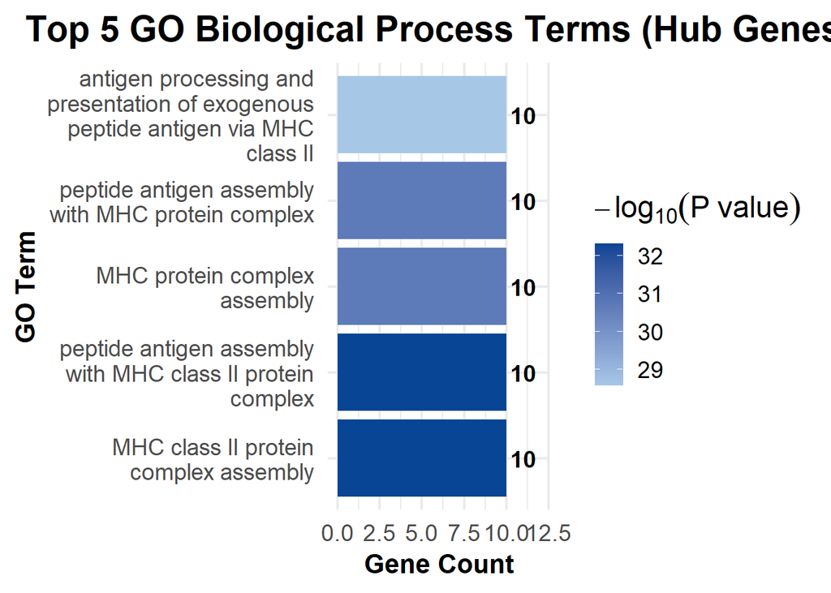

```r
# Wrap GO term text to two lines (e.g., 25 characters per line)
top5_hub$Term_wrapped <- str_wrap(top5_hub$Term, width = 25)
top5_hub$Term_wrapped <- factor(top5_hub$Term_wrapped, levels = top5_hub$Term_wrapped[order(top5_hub$Count)])

# Bar plot
ggplot(top5_hub, aes(x = Term_wrapped, y = Count, fill = -log10(`P value`))) +
  geom_bar(stat = "identity", width = 0.9) +
  coord_flip() +
  scale_fill_gradient(low = "#a7c7e7", high = "#084594", name = expression(-log[10](P~value))) +
  labs(
    title = "Top 5 GO Biological Process Terms (Hub Genes)",
    x = "GO Term",
    y = "Gene Count"
  ) +
  geom_text(aes(label = Count), hjust = -0.15, size = 5, fontface = "bold") +
  theme_minimal(base_size = 18) +
  theme(
    plot.title = element_text(hjust = 0.5, face = "bold"),
    axis.title.y = element_text(face = "bold", size = 16),
    axis.title.x = element_text(face = "bold", size = 16),
    axis.text.y = element_text(size = 14),
    legend.position = "right"
  ) +
  expand_limits(y = max(top5_hub$Count) + 2)
```

# 3.13 Survival Analysis

```r
#tcga
expr_tcga   <- read.delim("laml_tcga/data_mrna_seq_rpkm.txt", check.names=FALSE, header=TRUE)
mut_tcga   <- read.delim("laml_tcga/data_mutations.txt", header=TRUE, stringsAsFactors=FALSE, quote = "", comment.char = "")
pheno_tcga   <- read.delim("laml_tcga/data_clinical_sample.txt", header=TRUE, stringsAsFactors=FALSE, skip=4)
pheno_tcga_patient   <- read.delim("laml_tcga/data_clinical_patient.txt", header=TRUE, stringsAsFactors=FALSE, skip = 4)


# 1. Identify RUNX1-mutant samples from mut_tcga
runx1_mut_samples <- unique(mut_tcga$Tumor_Sample_Barcode[mut_tcga$Hugo_Symbol == "RUNX1"])

# 2. Get all samples in expr_tcga (expression columns, skipping gene info)
expr_samples <- colnames(expr_tcga)[-(1:2)]

# 3. Label each sample in expr_tcga as RUNX1 mutant or wildtype
runx1_status <- ifelse(expr_samples %in% runx1_mut_samples, "RUNX1_mut", "RUNX1_wildtype")
status_df <- data.frame(SAMPLE_ID = expr_samples, RUNX1_status = runx1_status)


# Merge to add SAMPLE_ID to pheno_ohsu22_patient
pheno_tcga_patient_with_sample <- merge(
  pheno_tcga_patient,
  pheno_tcga[, c("PATIENT_ID", "SAMPLE_ID")],
  by = "PATIENT_ID",
  all.x = TRUE
)

merged_tcga_df <- merge(pheno_tcga_patient_with_sample, status_df, by = "SAMPLE_ID", all = FALSE)

# Subset selected columns into a new dataframe
tcga_survival_df <- merged_tcga_df[, c("SAMPLE_ID", "OS_STATUS", "OS_MONTHS", "RUNX1_status")]


# Replace 'RUNX1_mut' with 'RUNX1_mutation'
tcga_survival_df$RUNX1_status[tcga_survival_df$RUNX1_status == "RUNX1_mut"] <- "RUNX1_mutation"

#ohsu18
expr_ohsu22 <- read.delim("aml_ohsu_2022/data_mrna_seq_rpkm.txt", check.names=FALSE, header=TRUE)
mut_ohsu22 <- read.delim("aml_ohsu_2022/data_mutations.txt", header=TRUE, stringsAsFactors=FALSE, quote = "", comment.char = "")
pheno_ohsu22 <- read.delim("aml_ohsu_2022/data_clinical_sample.txt", header=TRUE, stringsAsFactors=FALSE, skip=4)
pheno_ohsu22_patient <- read.delim("aml_ohsu_2022/data_clinical_patient.txt", header=TRUE, stringsAsFactors=FALSE, skip=4)


# View the first few rows to confirm

# 1. Identify samples with RUNX1 mutation from mut_ohsu22
runx1_mut_samples <- unique(mut_ohsu22$Tumor_Sample_Barcode[mut_ohsu22$Hugo_Symbol == "RUNX1"])

# 2. List all expression sample IDs from expr_ohsu22 (excluding gene column)
expr_samples <- colnames(expr_ohsu22)[-1]

# 3. Assign mutation status to each expression sample
runx1_status <- ifelse(expr_samples %in% runx1_mut_samples, "RUNX1_mutation", "wildtype")

# 4. Create a data frame with sample IDs and status
runx1_status_df <- data.frame(SAMPLE_ID = expr_samples, RUNX1_status = runx1_status)

# 5. Output lists
runx1_mut_list <- runx1_status_df$SAMPLE_ID[runx1_status_df$RUNX1_status == "RUNX1_mutation"]
runx1_wt_list  <- runx1_status_df$SAMPLE_ID[runx1_status_df$RUNX1_status == "wildtype"]


# Merge to add SAMPLE_ID to pheno_ohsu22_patient
pheno_ohsu22_patient_with_sample <- merge(
  pheno_ohsu22_patient,
  pheno_ohsu22[, c("PATIENT_ID", "SAMPLE_ID")],
  by = "PATIENT_ID",
  all.x = TRUE
)

merged_ohsu22_df <- merge(pheno_ohsu22_patient_with_sample, runx1_status_df, by = "SAMPLE_ID", all = FALSE)

# Subset selected columns into a new dataframe
ohsu22_survival_df <- merged_ohsu22_df[, c("SAMPLE_ID", "OS_STATUS", "OS_MONTHS", "RUNX1_status")]

# Replace 'wildtype' with 'RUNX1_wildtype'
ohsu22_survival_df$RUNX1_status[ohsu22_survival_df$RUNX1_status == "wildtype"] <- "RUNX1_wildtype"

#ohsu18
expr_ohsu18 <- read.delim("aml_ohsu_2018/data_mrna_seq_rpkm.txt", check.names=FALSE, header=TRUE)
mut_ohsu18 <- read.delim("aml_ohsu_2018/data_mutations.txt", header=TRUE, stringsAsFactors=FALSE, quote = "", comment.char = "")
pheno_ohsu18 <- read.delim("aml_ohsu_2018/data_clinical_sample.txt", header=TRUE, stringsAsFactors=FALSE, skip=4)
pheno_ohsu18_patient <- read.delim("aml_ohsu_2018/data_clinical_patient.txt", header=TRUE, stringsAsFactors=FALSE, skip=4)
# 1. Identify samples with RUNX1 mutation from mut_ohsu18
runx1_mut_samples_18 <- unique(mut_ohsu18$Tumor_Sample_Barcode[mut_ohsu18$Hugo_Symbol == "RUNX1"])

# 2. List all expression sample IDs from expr_ohsu18 (excluding gene columns)
expr_samples_18 <- colnames(expr_ohsu18)[-c(1,2)]  # Skip Hugo_Symbol and Entrez_Gene_Id

# 3. Assign mutation status to each expression sample
runx1_status_18 <- ifelse(expr_samples_18 %in% runx1_mut_samples_18, "RUNX1_mutation", "wildtype")

# 4. Create a data frame with sample IDs and status
runx1_status_df_18 <- data.frame(SAMPLE_ID = expr_samples_18, RUNX1_status = runx1_status_18)

# 5. Output lists of RUNX1 mutant and wildtype sample IDs
runx1_mut_list_18 <- runx1_status_df_18$SAMPLE_ID[runx1_status_df_18$RUNX1_status == "RUNX1_mutation"]
runx1_wt_list_18  <- runx1_status_df_18$SAMPLE_ID[runx1_status_df_18$RUNX1_status == "wildtype"]


# Merge to add SAMPLE_ID to pheno_ohsu18_patient
pheno_ohsu18_patient_with_sample <- merge(
  pheno_ohsu18_patient,
  pheno_ohsu18[, c("PATIENT_ID", "SAMPLE_ID")],
  by = "PATIENT_ID",
  all.x = TRUE
)

merged_ohsu18_df <- merge(pheno_ohsu18_patient_with_sample, runx1_status_df_18, by = "SAMPLE_ID", all = FALSE)


# Subset selected columns into a new dataframe
ohsu18_survival_df <- merged_ohsu18_df[, c("SAMPLE_ID", "OS_STATUS", "OS_MONTHS", "RUNX1_status")]

# Replace 'wildtype' with 'RUNX1_wildtype' in RUNX1_status column
ohsu18_survival_df$RUNX1_status[ohsu18_survival_df$RUNX1_status == "wildtype"] <- "RUNX1_wildtype"


combined_survival_df1 <- rbind(tcga_survival_df, ohsu22_survival_df, ohsu18_survival_df)


# Extract status (0 or 1) from "0:LIVING" / "1:DECEASED"
combined_survival_df1$OS_event <- ifelse(grepl("DECEASED", combined_survival_df1$OS_STATUS), 1, 0)

# Ensure OS_MONTHS is numeric
combined_survival_df1$OS_MONTHS <- as.numeric(combined_survival_df1$OS_MONTHS)
# Check which rows are problematic
combined_survival_df1[is.na(as.numeric(combined_survival_df1$OS_MONTHS)), "OS_MONTHS"]
```

```
##  [1] NA NA NA NA NA NA NA NA NA NA NA NA NA NA NA NA NA NA NA NA NA NA NA NA NA
## [26] NA NA NA NA NA NA NA NA NA NA NA NA NA NA NA NA NA NA NA NA NA NA NA NA NA
## [51] NA NA NA NA NA NA
```

```r
sum(!is.na(combined_survival_df1$OS_MONTHS))
```

```
## [1] 1245
```

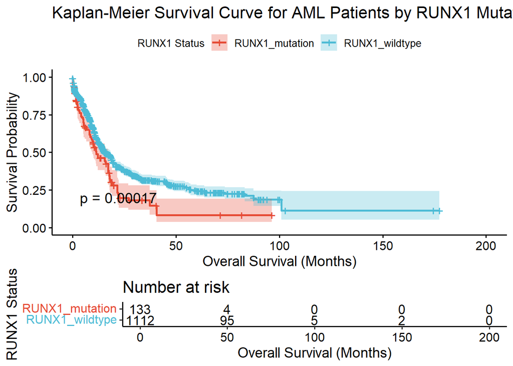

```r
surv_data <- combined_survival_df1[!is.na(combined_survival_df1$OS_MONTHS) & !is.na(combined_survival_df1$OS_event), ]


# Create the survival object
surv_obj <- Surv(time = surv_data$OS_MONTHS, event = surv_data$OS_event)

# Fit survival model by RUNX1 mutation status
fit <- survfit(surv_obj ~ RUNX1_status, data = surv_data)

# Plot the Kaplan-Meier curve
ggsurvplot(
  fit,
  data = surv_data,
  pval = TRUE,
  conf.int = TRUE,
  risk.table = TRUE,
  legend.labs = c("RUNX1_mutation", "RUNX1_wildtype"),
  legend.title = "RUNX1 Status",
  title = "Kaplan-Meier Survival Curve for AML Patients by RUNX1 Mutation",
  xlab = "Overall Survival (Months)",
  ylab = "Survival Probability",
  palette = c("#E64B35", "#4DBBD5")
)
```

```r
# Create survival object
surv_obj <- Surv(time = surv_data$OS_MONTHS, event = surv_data$OS_event)

# Fit Cox proportional hazards model
cox_model <- coxph(surv_obj ~ RUNX1_status, data = surv_data)

# View model summary
summary(cox_model)
```

```
## Call:
## coxph(formula = surv_obj ~ RUNX1_status, data = surv_data)
##
##   n= 1245, number of events= 744
##
##                               coef exp(coef) se(coef)      z Pr(>|z|)
## RUNX1_statusRUNX1_wildtype -0.4056    0.6666   0.1087 -3.731 0.000191 ***
## ---
## Signif. codes:  0 '***' 0.001 '**' 0.01 '*' 0.05 '.' 0.1 ' ' 1
##
##                            exp(coef) exp(-coef) lower .95 upper .95
## RUNX1_statusRUNX1_wildtype    0.6666        1.5    0.5386    0.8249
##
## Concordance= 0.519  (se = 0.006 )
## Likelihood ratio test= 12.61  on 1 df,   p=4e-04
## Wald test            = 13.92  on 1 df,   p=2e-04
## Score (logrank) test = 14.11  on 1 df,   p=2e-04
```